# Practical Machine Learning - Course Project

Daniel Harcek

20 March 2015

## Synopsis

#### predmachlearn-012 // 6th of April 2015

Predict activity quality class (see below) based on data gathered from accelerometers on the belt, forearm, arm, and dumbell.

You should

- create a report describing how you built your model,
- how you used cross validation,
- what you think the expected out of sample error is,
- and why you made the choices you did.

You will also use your prediction model to predict 20 different test cases.

## Description

Using devices such as Jawbone Up, Nike FuelBand, and Fitbit it is now possible to collect a large amount of data about personal activity relatively inexpensively. These type of devices are part of the quantified self movement – a group of enthusiasts who take measurements about themselves regularly to improve their health, to find patterns in their behavior, or because they are tech geeks. **One thing that people regularly do is quantify how much of a particular activity they do, but they rarely quantify how well they do it**. In this project, your goal will be to use data from accelerometers on the belt, forearm, arm, and dumbell of 6 participants. They were asked to perform barbell lifts **correctly and incorrectly in 5 different ways**. More information is available from the website here: http://groupware.les.inf.puc-rio.br/har (see the section on the Weight Lifting Exercise Dataset).

The training data for this project are available here: https://d396qusza40orc.cloudfront.net/predmachlearn/pml-training.csv

The test data are available here: https://d396qusza40orc.cloudfront.net/predmachlearn/pml-testing.csv

Six young health participants were asked to perform one set of 10 repetitions of the Unilateral Dumbbell Biceps Curl in five different fashions:

- exactly according to the specification (Class A)
- throwing the elbows to the front (Class B)
- lifting the dumbbell only halfway (Class C)
- lowering the dumbbell only halfway (Class D)
- throwing the hips to the front (Class E).

Read more: http://groupware.les.inf.puc-rio.br/har#ixzz3UxT89OCG

## R-Part

### Load necessary libraries

We load both `rpart` and `randomForest` because as we will later see, regular decision tree performs with low prediction precission so we experiment instead with `randomForest`.

```r
library("caret")
```

```r
library("corrplot")
library("rpart")
library("rattle")
library("rpart.plot")
library("randomForest")
```

### Download and load the data

We download the data if they are not present in working directory and load datasets into the memory.

```r
URL_BASE <- "https://d396qusza40orc.cloudfront.net/predmachlearn/"
DATA_TRAINING <- "pml-training.csv"
DATA_TESTING <- "pml-testing.csv"
if (!(file.exists(DATA_TRAINING))) {
  download.file(url=paste(URL_BASE, DATA_TRAINING, sep=""), destfile=DATA_TRAINING, method="curl")
  download.file(url=paste(URL_BASE, DATA_TESTING, sep=""), destfile=DATA_TESTING, method="curl")
}

activity_training <- read.csv(file=DATA_TRAINING, head=TRUE, sep=",", na.strings=c("NA","#DIV/0!",""))
activity_test <- read.csv(file=DATA_TESTING, head=TRUE, sep=",", na.strings=c("NA","#DIV/0!",""))
```

### Preparing the dataset

We start exploring the data. We see that the number of the predictors is quite hi, but looking at the summary and complete cases we can see that there is a lot of columns with high number of NA’s.

```r
ncol(activity_training)
```

```
## [1] 160
```

```r
str(activity_training)
```

```
## 'data.frame':    19622 obs. of  160 variables:
##  $ X                       : int  1 2 3 4 5 6 7 8 9 10 ...
##  $ user_name               : Factor w/ 6 levels "adelmo","carlitos",..: 2 2 2 2 2 2 2 2 2 2 ...
##  $ raw_timestamp_part_1    : int  1323084231 1323084231 1323084231 1323084232 1323084232 1323084232 1323084232 1323084232 1323084232 1323084232 ...
##  $ raw_timestamp_part_2    : int  788290 808298 820366 120339 196328 304277 368296 440390 484323 484434 ...
##  $ cvtd_timestamp          : Factor w/ 20 levels "02/12/2011 13:32",..: 9 9 9 9 9 9 9 9 9 9 ...
##  $ new_window              : Factor w/ 2 levels "no","yes": 1 1 1 1 1 1 1 1 1 1 ...
##  $ num_window              : int  11 11 11 12 12 12 12 12 12 12 ...
##  $ roll_belt               : num  1.41 1.41 1.42 1.48 1.48 1.45 1.42 1.42 1.43 1.45 ...
##  $ pitch_belt              : num  8.07 8.07 8.07 8.05 8.07 8.06 8.09 8.13 8.16 8.17 ...
##  $ yaw_belt                : num  -94.4 -94.4 -94.4 -94.4 -94.4 -94.4 -94.4 -94.4 -94.4 -94.4 ...
##  $ total_accel_belt        : int  3 3 3 3 3 3 3 3 3 3 ...
##  $ kurtosis_roll_belt      : num  NA NA NA NA NA NA NA NA NA NA ...
##  $ kurtosis_picth_belt     : num  NA NA NA NA NA NA NA NA NA NA ...
##  $ kurtosis_yaw_belt       : logi  NA NA NA NA NA NA ...
```

[output cut: 86 more lines]

```r
summary(activity_training) # remove data with a lot of NA's
```

```
##        X            user_name    raw_timestamp_part_1 raw_timestamp_part_2
##  Min.   :    1   adelmo  :3892   Min.   :1.322e+09    Min.   :   294
##  1st Qu.: 4906   carlitos:3112   1st Qu.:1.323e+09    1st Qu.:252912
##  Median : 9812   charles :3536   Median :1.323e+09    Median :496380
##  Mean   : 9812   eurico  :3070   Mean   :1.323e+09    Mean   :500656
##  3rd Qu.:14717   jeremy  :3402   3rd Qu.:1.323e+09    3rd Qu.:751891
##  Max.   :19622   pedro   :2610   Max.   :1.323e+09    Max.   :998801
##
##           cvtd_timestamp  new_window    num_window      roll_belt
##  28/11/2011 14:14: 1498   no :19216   Min.   :  1.0   Min.   :-28.90
##  05/12/2011 11:24: 1497   yes:  406   1st Qu.:222.0   1st Qu.:  1.10
##  30/11/2011 17:11: 1440               Median :424.0   Median :113.00
##  05/12/2011 11:25: 1425               Mean   :430.6   Mean   : 64.41
##  02/12/2011 14:57: 1380               3rd Qu.:644.0   3rd Qu.:123.00
##  02/12/2011 13:34: 1375               Max.   :864.0   Max.   :162.00
##  (Other)         :11007
##    pitch_belt          yaw_belt       total_accel_belt kurtosis_roll_belt
##  Min.   :-55.8000   Min.   :-180.00   Min.   : 0.00    Min.   :-2.121
##  1st Qu.:  1.7600   1st Qu.: -88.30   1st Qu.: 3.00    1st Qu.:-1.329
##  Median :  5.2800   Median : -13.00   Median :17.00    Median :-0.899
##  Mean   :  0.3053   Mean   : -11.21   Mean   :11.31    Mean   :-0.220
##  3rd Qu.: 14.9000   3rd Qu.:  12.90   3rd Qu.:18.00    3rd Qu.:-0.219
##  Max.   : 60.3000   Max.   : 179.00   Max.   :29.00    Max.   :33.000
##                                                        NA's   :19226
##  kurtosis_picth_belt kurtosis_yaw_belt skewness_roll_belt
##  Min.   :-2.190      Mode:logical      Min.   :-5.745
##  1st Qu.:-1.107      NA's:19622        1st Qu.:-0.444
##  Median :-0.151                        Median : 0.000
##  Mean   : 4.334                        Mean   :-0.026
##  3rd Qu.: 3.178                        3rd Qu.: 0.417
##  Max.   :58.000                        Max.   : 3.595
##  NA's   :19248                         NA's   :19225
##  skewness_roll_belt.1 skewness_yaw_belt max_roll_belt     max_picth_belt
##  Min.   :-7.616       Mode:logical      Min.   :-94.300   Min.   : 3.00
##  1st Qu.:-1.114       NA's:19622        1st Qu.:-88.000   1st Qu.: 5.00
##  Median :-0.068                         Median : -5.100   Median :18.00
##  Mean   :-0.296                         Mean   : -6.667   Mean   :12.92
##  3rd Qu.: 0.661                         3rd Qu.: 18.500   3rd Qu.:19.00
##  Max.   : 7.348                         Max.   :180.000   Max.   :30.00
##  NA's   :19248                          NA's   :19216     NA's   :19216
```

[output cut: 313 more lines]

```
##  Min.   :-446.00   Min.   :-1280.0   Min.   :-896.0   Min.   :-973.0
##  1st Qu.:-182.00   1st Qu.: -616.0   1st Qu.:   2.0   1st Qu.: 191.0
##  Median : -39.00   Median : -378.0   Median : 591.0   Median : 511.0
##  Mean   : -55.29   Mean   : -312.6   Mean   : 380.1   Mean   : 393.6
##  3rd Qu.:  26.00   3rd Qu.:  -73.0   3rd Qu.: 737.0   3rd Qu.: 653.0
##  Max.   : 291.00   Max.   :  672.0   Max.   :1480.0   Max.   :1090.0
##
##  classe
##  A:5580
##  B:3797
##  C:3422
##  D:3216
##  E:3607
##
##
```

```r
table(complete.cases(activity_training))
```

```
##
## FALSE
## 19622
```

We will all such data (majority of NA’s in predictor observations) and we remove also variables giving no information in relation to predicted class as a timestamp, user name etc.

```r
activity_training_wo_na <- activity_training[,colSums(is.na(activity_training)) < 19000]
table(complete.cases(activity_training_wo_na))
```

```
##
##  TRUE
## 19622
```

```r
nrow(activity_training_wo_na)
```

```
## [1] 19622
```

```r
ncol(activity_training_wo_na)
```

```
## [1] 60
```

```r
activity_training_tidy <- activity_training_wo_na[ ,!(names(activity_training_wo_na) %in% c("X", "user_name", "raw_timestamp_part_1", "raw_timestamp_part_2", "cvtd_timestamp", "new_window", "num_window"))]
ncol(activity_training_tidy)
```

```
## [1] 53
```

```r
nearZeroVar(subset(activity_training_tidy, select=-c(classe)), saveMetrics=TRUE)
```

```
##                      freqRatio percentUnique zeroVar   nzv
## roll_belt             1.101904     6.7781062   FALSE FALSE
## pitch_belt            1.036082     9.3772296   FALSE FALSE
## yaw_belt              1.058480     9.9734991   FALSE FALSE
## total_accel_belt      1.063160     0.1477933   FALSE FALSE
## gyros_belt_x          1.058651     0.7134849   FALSE FALSE
## gyros_belt_y          1.144000     0.3516461   FALSE FALSE
## gyros_belt_z          1.066214     0.8612782   FALSE FALSE
## accel_belt_x          1.055412     0.8357966   FALSE FALSE
## accel_belt_y          1.113725     0.7287738   FALSE FALSE
## accel_belt_z          1.078767     1.5237998   FALSE FALSE
## magnet_belt_x         1.090141     1.6664968   FALSE FALSE
## magnet_belt_y         1.099688     1.5187035   FALSE FALSE
## magnet_belt_z         1.006369     2.3290184   FALSE FALSE
## roll_arm             52.338462    13.5256345   FALSE FALSE
## pitch_arm            87.256410    15.7323412   FALSE FALSE
## yaw_arm              33.029126    14.6570176   FALSE FALSE
## total_accel_arm       1.024526     0.3363572   FALSE FALSE
## gyros_arm_x           1.015504     3.2769341   FALSE FALSE
## gyros_arm_y           1.454369     1.9162165   FALSE FALSE
## gyros_arm_z           1.110687     1.2638875   FALSE FALSE
## accel_arm_x           1.017341     3.9598410   FALSE FALSE
## accel_arm_y           1.140187     2.7367241   FALSE FALSE
## accel_arm_z           1.128000     4.0362858   FALSE FALSE
## magnet_arm_x          1.000000     6.8239731   FALSE FALSE
## magnet_arm_y          1.056818     4.4439914   FALSE FALSE
## magnet_arm_z          1.036364     6.4468454   FALSE FALSE
## roll_dumbbell         1.022388    84.2065029   FALSE FALSE
## pitch_dumbbell        2.277372    81.7449801   FALSE FALSE
## yaw_dumbbell          1.132231    83.4828254   FALSE FALSE
## total_accel_dumbbell  1.072634     0.2191418   FALSE FALSE
## gyros_dumbbell_x      1.003268     1.2282132   FALSE FALSE
## gyros_dumbbell_y      1.264957     1.4167771   FALSE FALSE
## gyros_dumbbell_z      1.060100     1.0498420   FALSE FALSE
## accel_dumbbell_x      1.018018     2.1659362   FALSE FALSE
## accel_dumbbell_y      1.053061     2.3748853   FALSE FALSE
## accel_dumbbell_z      1.133333     2.0894914   FALSE FALSE
## magnet_dumbbell_x     1.098266     5.7486495   FALSE FALSE
## magnet_dumbbell_y     1.197740     4.3012945   FALSE FALSE
## magnet_dumbbell_z     1.020833     3.4451126   FALSE FALSE
## roll_forearm         11.589286    11.0895933   FALSE FALSE
## pitch_forearm        65.983051    14.8557741   FALSE FALSE
## yaw_forearm          15.322835    10.1467740   FALSE FALSE
## total_accel_forearm   1.128928     0.3567424   FALSE FALSE
## gyros_forearm_x       1.059273     1.5187035   FALSE FALSE
## gyros_forearm_y       1.036554     3.7763735   FALSE FALSE
## gyros_forearm_z       1.122917     1.5645704   FALSE FALSE
## accel_forearm_x       1.126437     4.0464784   FALSE FALSE
## accel_forearm_y       1.059406     5.1116094   FALSE FALSE
## accel_forearm_z       1.006250     2.9558659   FALSE FALSE
## magnet_forearm_x      1.012346     7.7667924   FALSE FALSE
## magnet_forearm_y      1.246914     9.5403119   FALSE FALSE
## magnet_forearm_z      1.000000     8.5771073   FALSE FALSE
```

It seems that there are no zero variance predictors, let’s move on searching for highly correlated data. We compute the correlation matrix and quickly visually inspect the correlation plot.

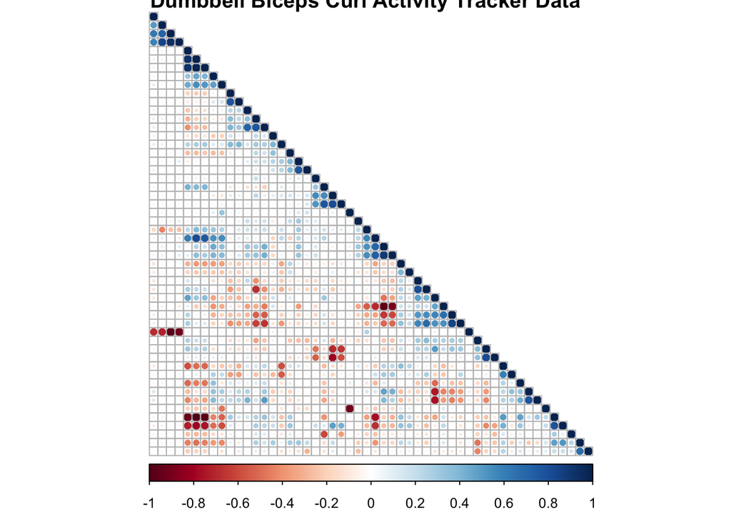

```r
cormatrix <- cor(subset(activity_training_tidy, select=-c(classe)))
corrplot(cormatrix, order = "hclust", type = "lower", main="Dumbbell Biceps Curl Activity Tracker Data", tl.pos="n")
```

We can see that there is couple of predictors with correlation over level 9 (which is a common default value for cutoff), so we will remove these.

```r
cutcorrelated <- findCorrelation(cormatrix, cutoff=.90, verbose=FALSE)
length(cutcorrelated)
```

```
## [1] 7
```

```r
activity_training_predictors <- activity_training_tidy[,-cutcorrelated]
dim(activity_training_predictors)
```

```
## [1] 19622    46
```

### Training and testing

We first split the data to training and test set.

```r
set.seed(8)
trainIndex <- createDataPartition(activity_training_predictors$classe, p=.60, list=FALSE)
train <- activity_training_predictors[trainIndex, ]
test <- activity_training_predictors[-trainIndex, ]
```

Finally we can train a simple classification tree on our data.

```r
fit <- train(classe ~ ., data=train, method="rpart")
```

And review properties of our tree.

```r
print(fit$finalModel)
```

```
## n= 11776
##
## node), split, n, loss, yval, (yprob)
##       * denotes terminal node
##
##  1) root 11776 8428 A (0.28 0.19 0.17 0.16 0.18)
##    2) pitch_forearm< -26.7 1035   41 A (0.96 0.04 0 0 0) *
##    3) pitch_forearm>=-26.7 10741 8387 A (0.22 0.21 0.19 0.18 0.2)
##      6) magnet_belt_y>=555.5 9877 7524 A (0.24 0.23 0.21 0.18 0.15)
##       12) magnet_dumbbell_y< 426.5 8096 5809 A (0.28 0.18 0.24 0.17 0.12)
##         24) roll_forearm< 122.5 5073 3024 A (0.4 0.18 0.18 0.14 0.089) *
##         25) roll_forearm>=122.5 3023 1989 C (0.079 0.17 0.34 0.22 0.18)
##           50) accel_forearm_x>=-101.5 2067 1259 C (0.091 0.21 0.39 0.085 0.22) *
##           51) accel_forearm_x< -101.5 956  460 D (0.052 0.1 0.24 0.52 0.09) *
##       13) magnet_dumbbell_y>=426.5 1781  985 B (0.037 0.45 0.048 0.21 0.26) *
##      7) magnet_belt_y< 555.5 864  163 E (0.0012 0.0023 0 0.19 0.81) *
```

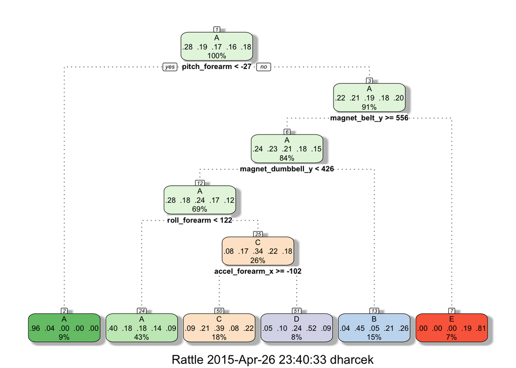

```r
fancyRpartPlot(fit$finalModel)
```

```r
prediction <- predict(fit, newdata=test)
confusionMatrix(prediction, test$classe)$overall
```

```
##       Accuracy          Kappa  AccuracyLower  AccuracyUpper   AccuracyNull
##      0.4973235      0.3431033      0.4861991      0.5084498      0.2844762
## AccuracyPValue  McnemarPValue
##      0.0000000      0.0000000
```

And we see that accuracy of trained decision tree is low. We try to improve this preprocessing the data with centering, scaling and doing 3 fold cross validation.

```r
fit <- train(classe ~ ., data=train, method="rpart",
              preProcess=c("center", "scale"),
              trControl=trainControl(method="cv", number=3, allowParallel=TRUE))

fit
```

```
## CART
##
## 11776 samples
##    45 predictor
##     5 classes: 'A', 'B', 'C', 'D', 'E'
##
## Pre-processing: centered, scaled
## Resampling: Cross-Validated (3 fold)
##
## Summary of sample sizes: 7851, 7851, 7850
##
## Resampling results across tuning parameters:
##
##   cp          Accuracy   Kappa       Accuracy SD  Kappa SD
##   0.03120551  0.4981314  0.34475487  0.02337229   0.03132112
##   0.03203607  0.4907429  0.33475173  0.01574466   0.02107955
##   0.06602990  0.3439097  0.09911024  0.10319300   0.17166396
##
## Accuracy was used to select the optimal model using  the largest value.
## The final value used for the model was cp = 0.03120551.
```

```r
prediction <- predict(fit, newdata=test)
confusionMatrix(prediction, test$classe)
```

```
## Confusion Matrix and Statistics
##
##           Reference
## Prediction    A    B    C    D    E
##          A 2035  634  631  505  307
##          B   50  526   44  243  273
##          C  110  304  548  128  315
##          D   35   52  143  304   58
##          E    2    2    2  106  489
##
## Overall Statistics
##
##                Accuracy : 0.4973
##                  95% CI : (0.4862, 0.5084)
##     No Information Rate : 0.2845
##     P-Value [Acc > NIR] : < 2.2e-16
##
##                   Kappa : 0.3431
##  Mcnemar's Test P-Value : < 2.2e-16
##
## Statistics by Class:
##
##                      Class: A Class: B Class: C Class: D Class: E
## Sensitivity            0.9117  0.34651  0.40058  0.23639  0.33911
## Specificity            0.6300  0.90360  0.86771  0.95610  0.98251
## Pos Pred Value         0.4949  0.46303  0.39004  0.51351  0.81364
## Neg Pred Value         0.9472  0.85216  0.87269  0.86463  0.86846
## Prevalence             0.2845  0.19347  0.17436  0.16391  0.18379
## Detection Rate         0.2594  0.06704  0.06984  0.03875  0.06232
## Detection Prevalence   0.5241  0.14479  0.17907  0.07545  0.07660
## Balanced Accuracy      0.7709  0.62506  0.63415  0.59624  0.66081
```

```r
confusionMatrix(prediction, test$classe)$overall
```

```
##       Accuracy          Kappa  AccuracyLower  AccuracyUpper   AccuracyNull
##      0.4973235      0.3431033      0.4861991      0.5084498      0.2844762
## AccuracyPValue  McnemarPValue
##      0.0000000      0.0000000
```

This did not bring any improvement at all. Let’s try random forest. Couple of observations here, I ended up using `randomForest` function since the `train` function from `caret` package was extremely slow. Some posts suggested to use `parRF` method in `caret` to speed things up, but it did not help. I did not used formula form as [advised here](http://stats.stackexchange.com/a/37382) and based on OOB (out of bag) error tracing decided seeing that OOB almost bottomed down around`` `ntree `` equal 300 to lower down the `ntree` value from `500` (OOB 0.87%) to `300` (OOB 0.91%).

```r
predictors <- subset(train, select=-c(classe))
decision <- subset(train, select=c(classe))
fit <- randomForest(predictors,decision[,1], prox=TRUE, ntree=300) # drop empty dimension https://stat.ethz.ch/pipermail/r-help/2008-July/166617.html

prediction <- predict(fit, newdata=test)
confusionMatrix(prediction, test$classe)$overall
```

```
##       Accuracy          Kappa  AccuracyLower  AccuracyUpper   AccuracyNull
##      0.9945195      0.9930674      0.9926248      0.9960310      0.2844762
## AccuracyPValue  McnemarPValue
##      0.0000000            NaN
```

### Prediction Assignment Submission

Let’s now remove all unused predictors from test data, generate predictions and prepare the submissions.

```r
activity_test_cleaned <- activity_test[names(activity_test) %in% colnames(activity_training_predictors)]
prediction <- predict(fit, newdata=activity_test_cleaned)
prediction
```

```
##  1  2  3  4  5  6  7  8  9 10 11 12 13 14 15 16 17 18 19 20
##  B  A  B  A  A  E  D  B  A  A  B  C  B  A  E  E  A  B  B  B
## Levels: A B C D E
```

```r
pml_write_files = function(x){
  n = length(x)
  for(i in 1:n){
    filename = paste0("problem_id_",i,".txt")
    write.table(x[i],file=filename,quote=FALSE,row.names=FALSE,col.names=FALSE)
  }
}

pml_write_files(prediction)
```